# **Classificazione della salute del feto**

Bonanomi Gervasoni Mahhadi

26 Gennaio 2024

#### *Abstract*

La lettura delle cardiotocografie CTGs, che sono registrazioni grafiche (tracciati) della frequenza cardiaca fetale durante la gravidanza, è soggetta a interpretazioni differenti quando viene eseguita da diversi operatori sanitari. Si tratta di una fase essenziale per valutare la salute del feto durante la gravidanza e il travaglio. Essa infatti influenza le decisioni sull’intervento del medico che, a seconda di come viene valutato il feto, opterà ad esempio per la somministrazione di ossigeno alla madre, o in casi più gravi, procederà con un taglio cesareo d’emergenza.

L’obiettivo di questa nostra analisi sarà costruire dei modelli in grado di prevedere con una buona accuratezza se il feto è Normale, Sospetto o Patologico. Utilizzeremo diverse metodologie di classificazione per valutare e costruire il modello che più si adatta ai nostri dati. A seguito di una breve analisi esplorativa verranno applicate in primis delle tecniche di clustering e successivamente una serie di modelli di classificazione di tipo EDDA o MDA supportate da tecniche di oversampling e undersampling.

### 1) Introduzione

La riduzione della mortalità neonatale fa parte dei principi cardine dell’Agenda 2030 per lo sviluppo sostenibile. Sottoscritta nel 2015 dai governi dei 193 membri delle Nazioni Unite, fra gli obiettivi che si prefigge vi è quello di porre fine alle morti prevenibili di neonati e bambini sotto i 5 anni di età. In particolare viene richiesto che tutti i paesi dovranno cercare di ridurre la mortalità neonatale ad almeno 12 per ogni 1000 abitanti nati vivi. Ad oggi però sono più di 60 gli stati lontani da questo traguardo e 2.3 milioni di neonati muoiono ogni anno. Di questi 904 400 neonati sopravvivono solo pochi giorni a causa di complicanze alla nascita, e oltre un milione sono quelli che muoiono durante il parto. La maggior parte di questi decessi sono causati dalla scarsa qualità dell’assistenza prima e durante il parto. Il miglioramento dei servizi sanitari e il potenziamento dei supporti informatici a costi accessibili, quindi, sono punti chiave per arginare queste tragedie.  
Fatte queste premesse, non si può non considerare la cardiotocografia computerizzata CTGc vista la posizione di primaria importanza che occupa nel fornire un ausilio al monitoraggio della salute del feto. Essa infatti è stata introdotta con l’obiettivo di ridurre i falsi positivi e la soggettività dell’interpretazione poichè fornisce un’interpretazione oggettiva della CTG consentendo la comunicazione di numeri piuttosto che di opinioni. Negli anni infatti ci si è resi conto che i risultati pratici conseguiti dall’uso «di massa» della cardiotocografia sono stati di gran lunga inferiori alle aspettative a causa della carenza di criteri univoci di interpretazione e alla scarsa preparazione degli operatori sanitari.  
Grazie alla cardiotocografia computerizzata, invece, non solo si riesce ad ottenere una migliore interpretazione del cardiotogramma, ma sfruttando la grande mole di dati raccolti, si è diffusa la sperimentazione di numerosi algoritmi di machine learning. Chiaramente l’introduzione di queste nuove tecniche fornisce risultati utili da valutare congiuntamente all’intero quadro clinico, senza quindi pretese di esaustività. Nel progetto seguente ci siamo cimentati nello sviluppare alcuni modelli coi quali identificare con maggior precisione quali sono i parametri che più di altri caratterizzano la salute del feto oltreché prevedere con minore margine di errore i casi che richiedono l’intervento ostetrico.

### 2) Materiali

I dati di interesse provengono dal dataset **fetal_health**, esportabile gratuitamente dal link citato a fine paragrafo. La raccolta di questi dati è stata fatta mediante SisPorto, un programma di analisi automatizzata del tracciato cardiotocografico che registra e riporta graficamente, l’attività elettrica del cuore e delle contrazioni uterine. Su queste calcola poi una serie di metriche che vengono valutate durante il monitoraggio cardiotografico del feto, così come indicato dalla FIGO (Federazione Internazionale di Ginecologia e Ostetricia).  
Tramite queste rilevazioni si è ottenuto un dataset con 2126 osservazioni di cardiotocografie fetali suddivise per 21 variabili a cui si somma l’etichetta di classe *fetal_health* rappresentata dalle modalità Normale, Sospetto, Patologico. Nel contesto valutativo della cardiotocografia un tracciato è definito:

**Normale** se la frequenza cardiaca fetale e la variabilità, così come le contrazioni uterine, rientrano negli intervalli attesi. Ciò suggerisce che il feto è in buona salute e sta ricevendo un adeguato apporto di ossigeno.  
**Sospetto** quando i valori ottenuti mostrano deviazioni lievi dalla norma, senza implicare necessariamente un problema grave. Potrebbe segnalare la necessità di ulteriori monitoraggi o valutazioni per garantire il benessere del feto. Questa categoria potrebbe includere pattern non ottimali ma che non suggeriscono immediatamente una condizione patologica.  
**Patologico** se presenti anomalie che possono rappresentare un rischio per la salute del feto. Ciò potrebbe includere pattern come decelerazioni prolungate, ridotta variabilità o altre irregolarità sintomo di una possibile sofferenza o compromessa ossigenazione del feto. In tali casi, potrebbe essere necessaria un’azione medica e ulteriori valutazioni per affrontare le problematiche sottostanti.

Per completezza di informazione segue una tabella che riporta sinteticamente la descrizione e le modalità delle variabili:

| VARIABILE | DESCRIZIONE | MODALITÀ |
| --- | --- | --- |
| baseline_value | Frequenza cardiaca fetale di base (FHR) | Valore in Bpm |
| accelerations | Numero di accelerazioni cardiache al secondo | Valore in Hz |
| fetal_movement | Numero di accelerazioni fetali al secondo | Valore in Hz |
| uterine_contractions | Numero di contrazioni uterine al secondo | Valore in Hz |
| light_decelerations | Numero di decelerazioni leggere al secondo | Valore in Hz |
| prolongued_decelerations | Numero di decelerazioni prolungate al secondo | Valore in Hz |
| mean_value_of_short_term_variability | Media della variabilità a breve termine | Valore in Millisecondi |
| percentage_of_time_with_abnormal_long_term… | Percentuale di tempo con variabilità a lungo termine anomala | Valore in Percentuale |
| mean_value_of_long_term_variability | Media della variabilità a lungo termine | Valore in Millisecondi |
| histogram_width | Larghezza dell’istogramma della FHR | Valore in Bpm |
| histogram_min | Valore minimo dell’istogramma della FHR | Valore in Bpm |
| histogram_max | Valore massimo dell’istogramma della FHR | Valore in Bpm |
| histogram_number_of_peaks | Numero di picchi nell’istogramma della FHR | Valore numerico (conteggio) |
| histogram_number_of_zeroes | Numero di zeri nell’istogramma della FHR | Valore numerico (conteggio) |
| histogram_mode | Moda dell’istogramma della FHR | Valore in Bpm |
| histogram_mean | Valore medio dell’istogramma della FHR | Valore in Bpm |
| histogram_median | Mediana dell’istogramma della FHR | Valore in Bpm |
| histogram_variance | Varianza dell’istogramma della FHR | Valore in Bpm^2 |
| histogram_tendency | Asimmetria dell’istogramma della FHR | **-1**:sinistra **0**:simmetrica **1**:destra |
| fetal_health | Salute del feto (etichetta di classe) | **1**:Sano **2**:Sospetto **3**:Patologico |

Il dataset non presenta valori mancanti. Valutando la distribuzione delle variabili abbiamo visto come quelle di conteggio naturalmente seguono una distribuzione assimilabile a quella di Poisson di conseguenza si è optato per escluderle dalle successive analisi. È stata esclusa anche la variabile *histogram_tendency* poichè fattoriale.  
Le variabili *percentage_of_time_with_abnormal_long_term_variability* e *histogram_variance* non son state considerate perchè hanno un comportamento che si discosta fortemente da una distribuzione normale. Le restanti variabili escluse dimostravano una pronunciata asimmetria. Da un’analisi preliminare dell’istogramma delle frequenze relative condizionato per classi si evince come la classe dei sani è predominante, il che è fisiologico considerando che nella popolazione, l’incidenza di casi patologici è molto limitata:

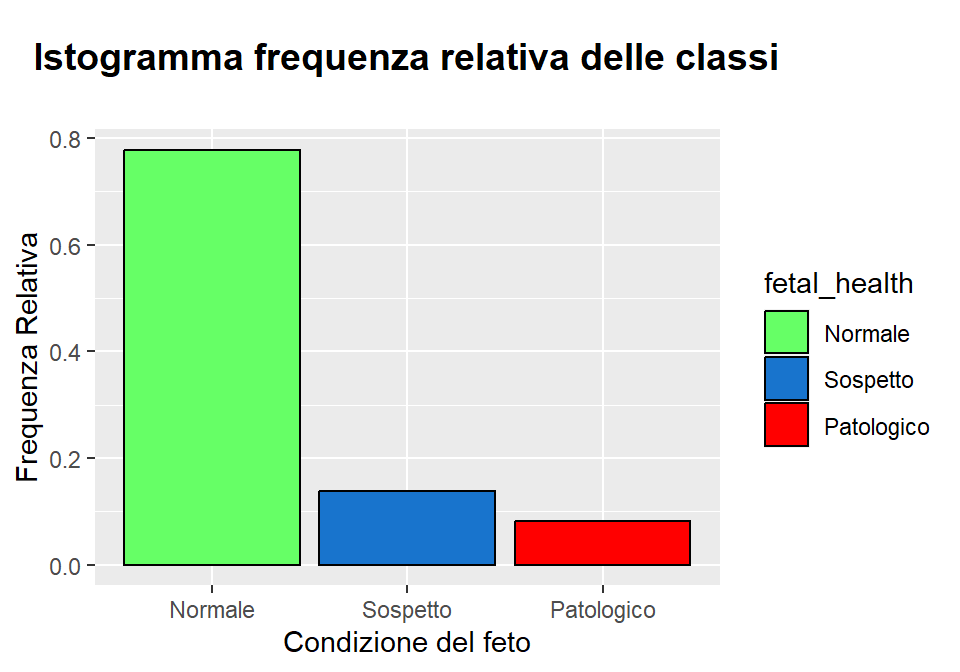

Ulteriori dettagli sul dataset sono presenti al seguente link: [Fetal Health Classification-Kaggle](https://www.kaggle.com/datasets/andrewmvd/fetal-health-classification/data%3E)

### 3) Analisi esplorativa

In prima analisi abbiamo deciso di analizzare la correlazione e la distribuzione delle variabili mediante ggpairs. Se ne è dedotto che le variabili *histogram_mean*, *histogram_median* e *histogram_mode* sono fortemente correlate, per cui è sufficiente mantere solo una delle tre. Non si riescono a dedurre osservazioni particolarmente utili per la fase di clustering a livello univariato o bivariato, ma ciò non esclude la presenza di gruppi a livello multivariato (non visualizzabili). Infine si nota che le variabili se distinte per fetal_health sono multimodali quindi successivamente implementeremo modelli di classificazione di tipo MDA. Inoltre essendo dati presi da macchine, è improbabile la presenza di errori dovuti a “data entry”.

Procediamo ora con l’analisi delle componenti principali eseguita su dati standardizzati considerata la presenza di valori con ordini di grandezza differenti. Abbiamo ottenuto che l’intera variabilità dei dati viene coperta per l’80% dalle prime 4 componenti. Si procede con la selezione delle 4 variabili in base ai loadings.

```
[1] "histogram_mean"                      "histogram_max"
[3] "mean_value_of_long_term_variability" "uterine_contractions"
```

Dopodiché abbiamo ripetuto il ggpairs sulle sole variabili selezionate. Notiamo che *mean_value_of_long_term_variability* e *uterine_contractions* non rispettano la normalità e la simmetria in tutti i gruppi essendo dati reali. Inoltre dallo scatterplot delle prime 2 variabili si evince una netta distinzione tra i gruppi coi casi sospetti che si collocano a destra dei sani e non tra sani e patologici, confermando l’anomalia delle osservazioni della seconda classe, sulle cui osservazioni sono richieste ulteriori analisi:

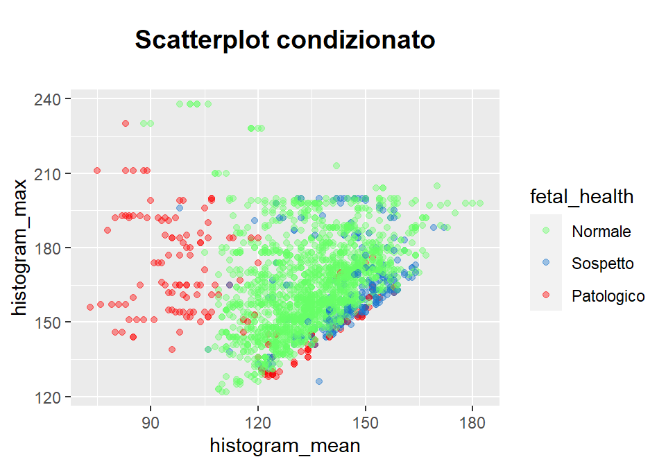

Fatte queste premesse, per il clustering abbiamo optato per il dataset con le sole variabili selezionate tramite i loadings così da avere una buona sintesi delle features a costo di perdere interpretabilità nei risultati. Segue la proiezione di un facetted box plot col quale rileviamo alcuni outlier che verranno conservati per mantenere la multimodalità:

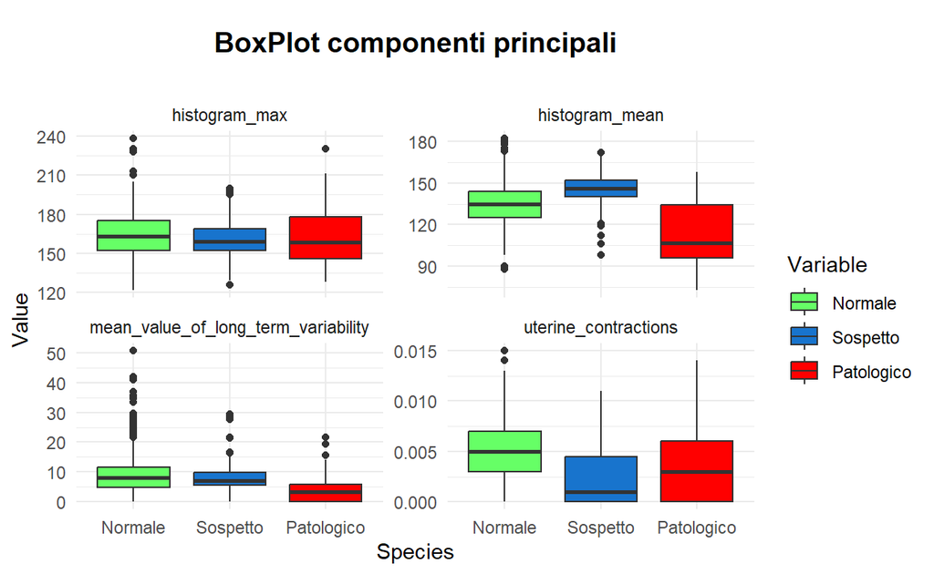

La classificazione non risulta evidente a livello univariato, se non per la variabile *histogram_mean*, ciò però non esclude la presenza di gruppi a livello bivariato e soprattutto multivariato (non visualizzabile graficamente). Si nota nuovamente, a sostegno delle osservazioni precedenti, che il gruppo dei sospetti risulta generalmente più simile al gruppo dei sani, almeno per 3 delle 4 variabili.

### 4) Model Based Clustering

Arrivati a questo punto, implementiamo un EM di normali senza specificare il numero dei gruppi:

```
Best ICL values:
             VEV,7         EVV,3       VEV,10
ICL      -29456.72 -29463.178690 -29534.63925
ICL diff      0.00     -6.460372    -77.92093
```

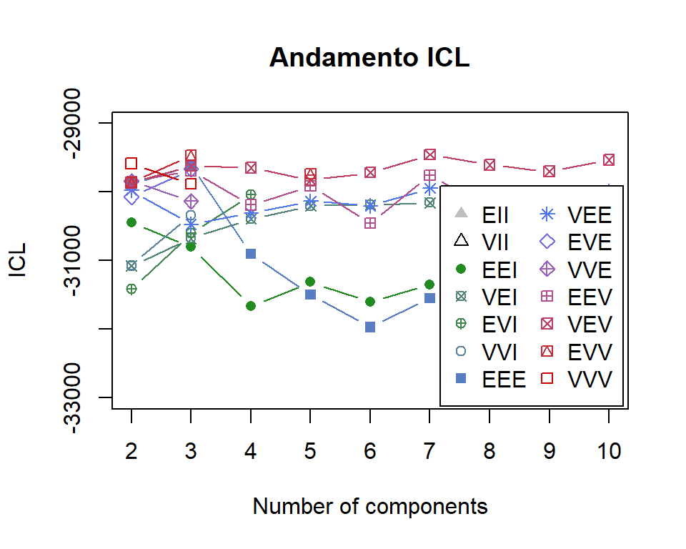

Provando a valutare il BIC (non accurato come ICL, in quanto non tiene conto dell’entropia) viene restituito un modello VEV k=8. In definitiva possiamo dire che l’EM è molto instabile e poco robusto per cui diventa cruciale la scelta dei valori iniziali. Difatti sia tramite ICL che con il BIC il model based clustering fornisce un numero di gruppi differente. Provando, invece, a specificare il numero dei gruppi pari a 3, sia ICL che BIC restituiscono il modello EVV. Per avere un riscontro visivo rappresentiamo il grafico della clusterizzazione ottenuta specificando il numero esatto dei gruppi:

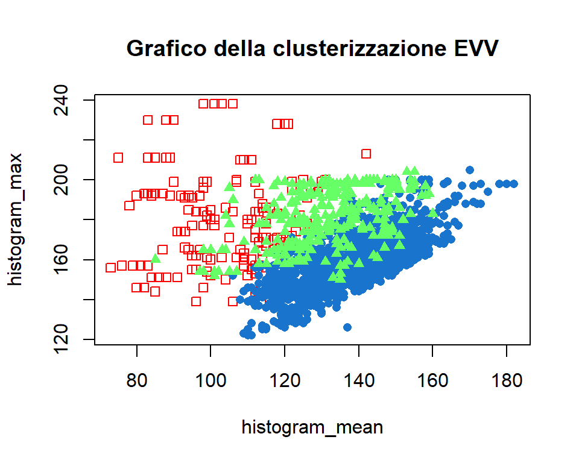

Ai fini di visualizzare meglio l’incertezza, invece, ci siamo serviti del grafico che segue. La colorazione dei punti ci permette di dedurre dove è stata allocata la corrispondente unità statistica, mentre l’incertezza della clusterizzazione aumenta al crescere delle dimensioni del punto:

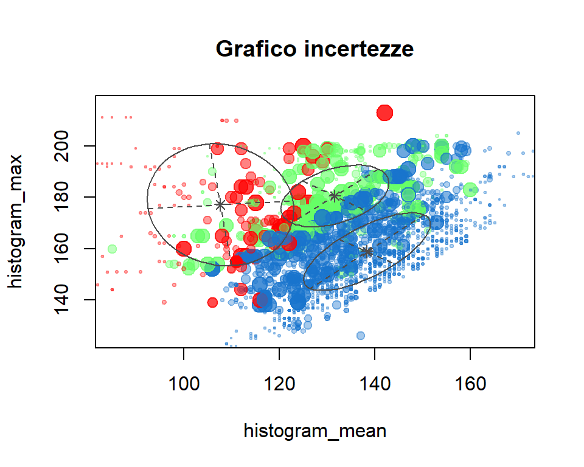

#### 4.2) Discussione dei risultati del clustering

Sia dal grafico che dalle medie stimate dei singoli gruppi si deduce chiaramente come l’EM non distingue correttamente i gruppi. In particolare, il gruppo dei sospetti viene completamente incluso all’interno dei normali e viene creata una nuova classe a noi sconosciuta che si colloca tra sani e i patologici. Quest’ultimo risulta essere, al netto di poche unità statistiche lontane dal baricentro, l’unico gruppo evidenziato correttamente. A seguito di queste osservazioni non è possibile effettuare dei confronti tramite una confusion matrix o calcolare degli indicatori come CER, adjusted rand index o accuracy (a parte sensitivity dei patologici: 0.78) avendo trovato una clusterizzazione scorretta. Per questo motivo è possibile fornire unicamente degli indicatori di bontà del modello che sottolineano nuovamente la bassa precisione delle analisi. In particolare abbiamo calcolato l’R^2 sia attraverso il determinante (0.73) che con la traccia (0.27). Al contrario per quanto riguarda l’individuazione dei cluster possiamo affermare che il modello risulta relativamente affidabile, infatti l’entropia relativa è pari a 0.15.  
Riteniamo opportuno confrontare i modelli VEV,7 ed EVV,3 che sono per distacco i migliori.  
Il modello con 7 gruppi in termini di bontà risulta migliore e lo si denota dal fatto che sia R^2 calcolato tramite determinante che quello calcolato tramite traccia sono superiori. Al contrario in termini di allocazione delle unità statistiche si denota un peggioramento osservabile dalla presenza di incertezza maggiore in ciascuna unità statistica e da un’entropia assoluta e relativa superiore.

```
             indice  EVV_3   VEV_7
1  R^2 determinante   0.73    0.89
2       R^2 traccia   0.27    0.39
3          entropia 356.00 1019.00
4 entropia relativa   0.15    0.25
```

### 5) Model Based Classification

Il primo step dell’analisi è stato quello di dividere il dataset in training e test set. In particolare, abbiamo assegnato, in modo casuale, il 70% delle osservazioni del dataset al training set e il restante 30% al test set. Questa fase è essenziale nel momento in cui si vanno ad applicare approcci di tipo supervisionato, il cui scopo è quello di fare generalizzazione e prevedere nuove istanze per la variabile target.

#### 5.2) EDDA (Valutato tramite Cross validation)

Ora che abbiamo ottenuto il traning set alleniamo un modello EDDA. Il modello allenato ci restituisce il modello VEV che valutiamo sul test set. Otteniamo la confusion matrix con un valore dell’accuracy dello 0.8447.

```
            Reference
Prediction   Normale Sospetto Patologico
  Normale        494       61         26
  Sospetto         1       20          9
  Patologico       0        1         19
```

L’accuracy è elevata solo a causa della differenza di numerosità tra le classi, per cui non è un buon indicatore per la bontà del modello. Difatti notiamo una mal classificazione sia nei casi sospetti sia, seppur in minor parte, nei casi patologici. Si può osservare tramite la confusion matrix o mediante le sensitivity molto basse (0.24 nei sospetti e 0.35 nei patologici). Plottando il grafico osserviamo un’elevata incertezza in diverse aree:

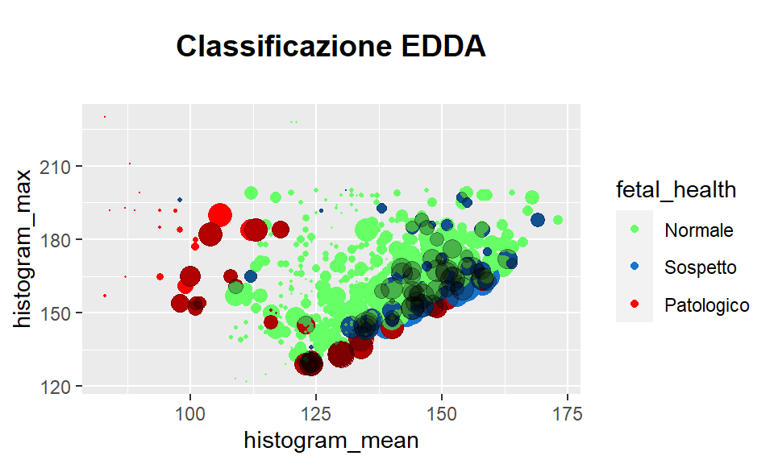

#### 5.3) MDA

Successivamente abbiamo implementato una funzione che valuta il miglior modello mda tramite cross validation con `nfold=4`, essendo un criterio più accurato rispetto al BIC. N.B. la stima del modello tramite cross validation richiede una potenza computazionale non indifferente, alla quale ovviamo con un vincolo, imponendo che il modello utilizzato in ciascuna delle classi sia di tipo VII da 1 a 5 gruppi.  
Si è visto empiricamente essere molto accurato, ma con un numero di parametri da stimare decisamente inferiore.

```
            Reference
Prediction   Normale Sospetto Patologico
  Normale        453       37         12
  Sospetto        34       43          8
  Patologico       8        2         34
```

#### 5.4) Smote 2.0

Proviamo a valutare i risultati ottenuti effettuando le analisi sul dataset dopo aver bilanciato le classi. A tale scopo ci serviamo di SMOTE, un algoritmo che genera sinteticamente nuovi esempi per le classi minoritarie, identificando i K-nearest neighbors (K-vicini prossimi) e creando combinazioni lineari tra le osservazioni esistenti. Questo processo migliora la rappresentazione della classe meno frequente nel dataset, aiutando i modelli di classificazione poiché li espone a più esempi di classi meno rappresentate cosicché la classificazione diventi più accurata.

Nel nostro caso applichiamo l’algoritmo smote per allenare il modello con 600 osservazioni per la classe dei patologici (quella di nostro interesse), 300 per la classe dei Sospetti e facciamo undersampling in modo che il classificatore venga allenato su 300 Normali. Inoltre utilizziamo il numero di “nearest neighbor” di default che è `k = 5`. Così facendo otteniamo un modello la cui confusion matrix presenta un minor numero di casi patologici e dubbiosi mal classificati. Oltretutto il rateo di patologici classificato come normale è calato drasticamente, il che è auspicabile rispetto a classificare i patologici come sani, e cioè non procedere con un taglio cesareo o con l’ossigenazione del feto quando necessario.

```
            Reference
Prediction   Normale Sospetto Patologico
  Normale        351       18          5
  Sospetto        83       54          6
  Patologico      61       10         43
```

```
                  Sensitivity Specificity
Class: Normale      0.7090909   0.8308824
Class: Sospetto     0.6585366   0.8378871
Class: Patologico   0.7962963   0.8769497
```

Dal grafico vediamo come le unità statistiche patologiche son ben distinguibili anche se distanti dai rispettivi baricentri:

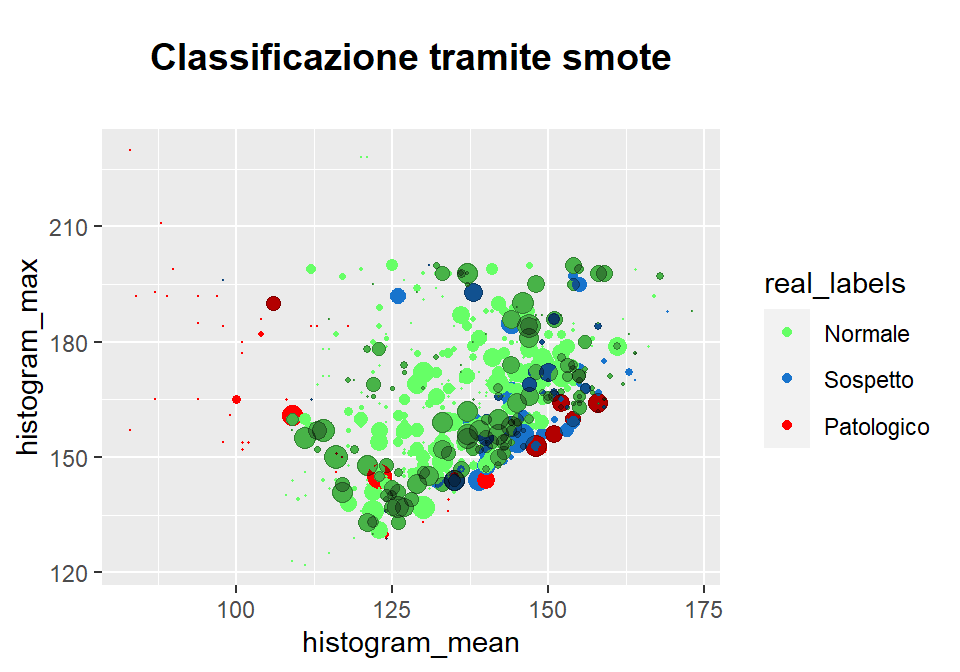

La scelta del modello MDA finale e delle unità statistiche utilizzate all’interno del training set (300 normali, 300 sospetti e 600 patologici) è volta a minimizzare l’errore di primo tipo ovvero classificare un soggetto patologico come sano e, a parità di errore di primo tipo, abbiamo optato per il modello che minimizza anche l’errore di secondo tipo ovvero classificare come patologico un soggetto che non lo è e di conseguenza effettuare interventi invasivi non necessari.

### 6) Conclusioni

In definitiva si può affermare che la classe dei casi sospetti è molto difficile da definire sia nei modelli di clustering che nei modelli di classification. Abbiamo anche osservato come i modelli di tipo MDA sono più accurati dei modelli EDDA, probabilmente a causa della presenza di sottogruppi in ciascuna classe. Tramite l’utilizzo di SMOTE e di un undersampling all’interno di un classificatore MDA otteniamo un risultato migliore per le classi minoritarie, ma ci appare evidente che lo scarso numero di osservazioni e l’accuratezza relativamente bassa rendano il nostro classificatore non attendibile per applicazioni mediche. Questi limiti intrinseci del nostro classificatore potrebbero essere superati ricorrendo a tecniche di machine learning più sofisticate che oltre a classificare meglio le unità statistiche, mantengono un certo grado di interpretabilità dei risultati, fondamentale per fornire risposte giustificate ai medici e rassicurare i pazienti.